# ML for Public Health hw2

Yujia Bai (Grace)

2022-04-20

```r
#read in necessary libraries
library(readr)
library(tidyverse)
library(splines)
library(gridExtra)
library(caret)
library(gam)
library(stats)
```

### 1. On canvas there is a dataset called `Chicago_air_quality.csv`. The data is derived from the National Morbidity, Mortality, and Air Pollution Study (NMMAPS).

In the dataset, each row represents a day and the included variables are: 1. Day: The study day (1-1000) 2. tmpd: The average temperature in Fahrenheit for the day 3. linear_pm25: Median particles < 2.5 mg per cubic m (measure of air quality). Missing data has been linearly interpolated 4. linear_pm10: Median particles 2.5-10 mg per cubic m. Missing data has been linearly interpolated 5. o3median: Median ozone in parts per billion 6. death: total deaths in the city for the day

Consider developing a predictor with the natural logarithm of the number of deaths as the outcome and the other variables as input features.

For this assignment, demonstrate at least three different basis function options for the features to predict the outcome, with the question of does air quality predict the mortality rate within a geographic region.

Explain why you chose the three different basis functions as candidate predictors and in a short paragraph explain how they performed for this task.

Using one of the resampling methods (bootstrap or cross-validation) estimate the predictive performance for each predictor.

How did the different predictors vary in their predictive performance?

```r
air <- read_csv("Chicago_air_quality.csv")
head(air)
```

```
## # A tibble: 6 x 6
##     Day  tmpd linear_pm25 linear_pm10 o3median death
##   <dbl> <dbl>       <dbl>       <dbl>    <dbl> <dbl>
## 1     1    35       11.5       54.3     -14.3    123
## 2     2    39       11.5       33.9     -12.9    125
## 3     3    41       10.4        0.254   -15.1    136
## 4     4    35        9.20     -20.8      -5.37   116
## 5     5    36        8.04       3.11    -11.0    119
## 6     6    38        6.88       0.152   -12.4    135
```

#### Observe data trends

```
## [1] "1"
```

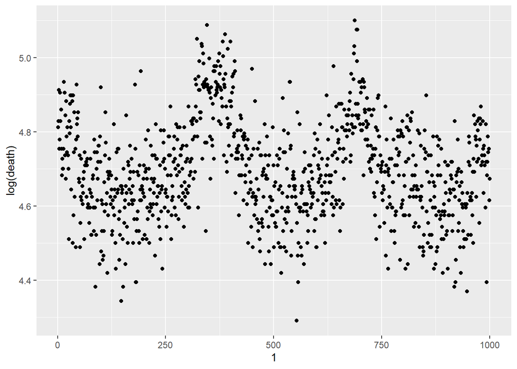

```
## [1] "2"
```

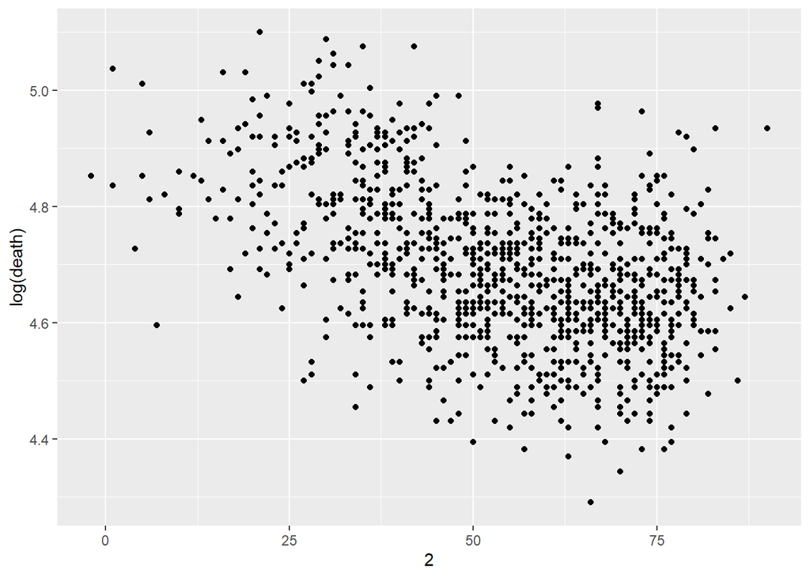

```
## [1] "3"
```

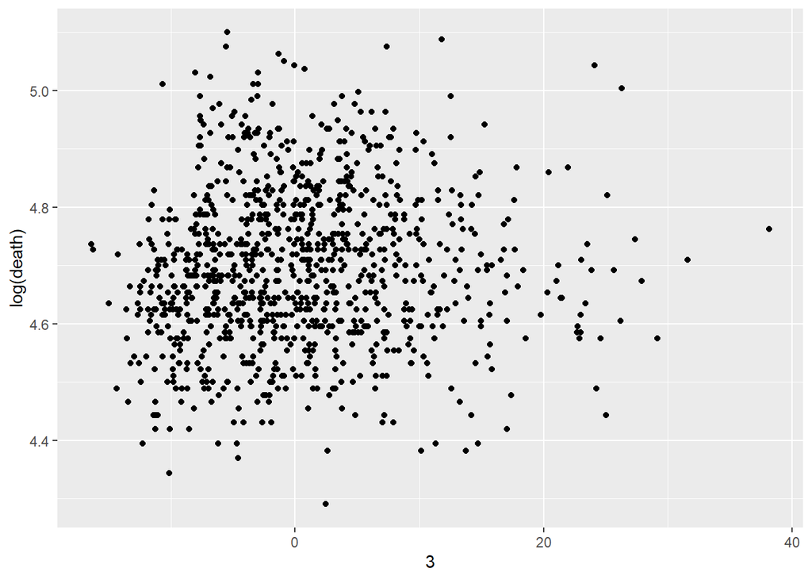

```
## [1] "4"
```

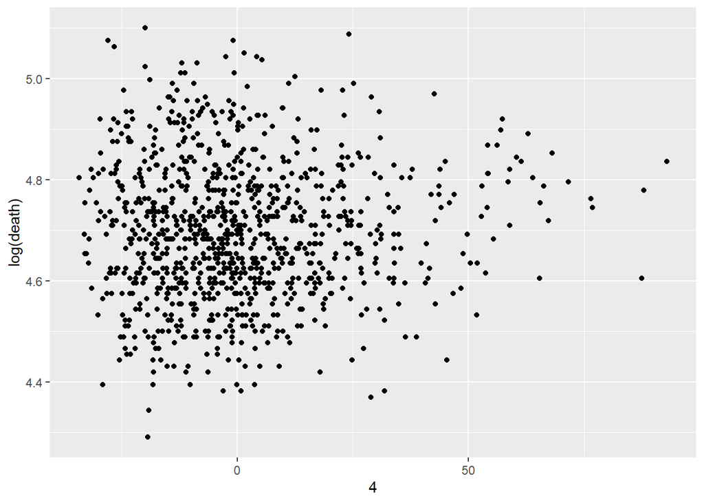

```
## [1] "5"
```

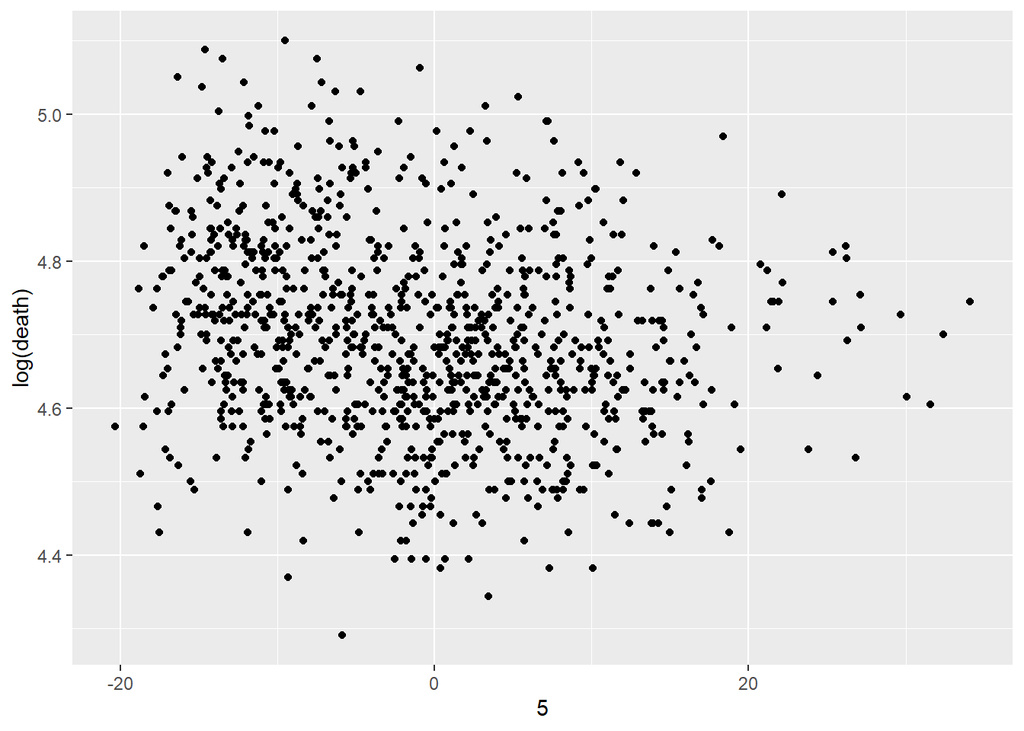

```r
#create list of all columns to loop through
ls.air <- list(air$Day, air$tmpd, air$linear_pm25, air$linear_pm10, air$o3median)

plots <- list()
for (i in 1:length(ls.air)){
 plots[[i]] <- print(ggplot(air, aes(x = ls.air[[i]], y = log(death))) +
  geom_point() +
  xlab(print(paste0(i))) +
  ylab("log(death)"))
 }
```

#### Check data distribution

##### from the histograms, we see that most variables in our data have a skewed distribution–>center and scale data

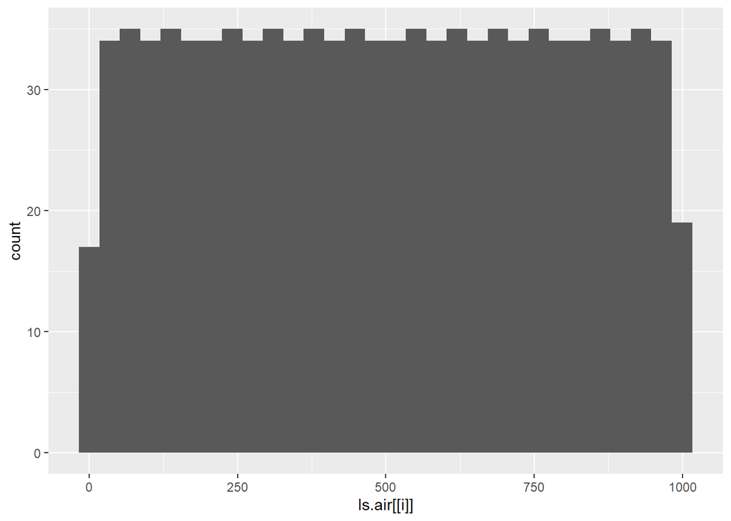

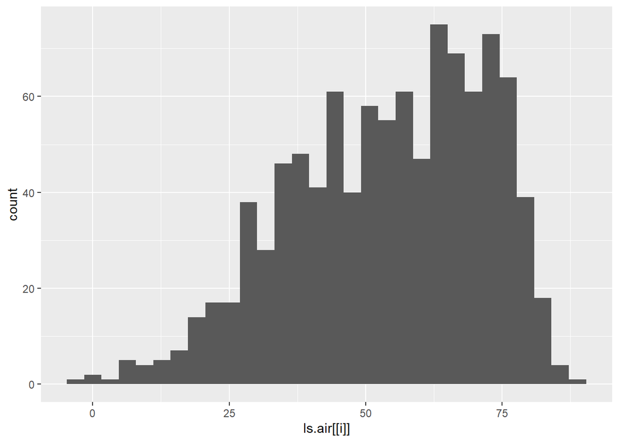

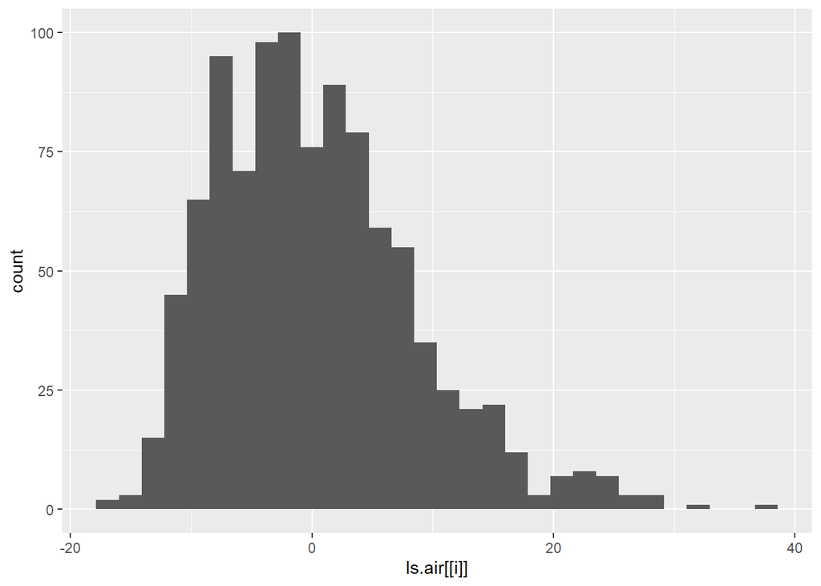

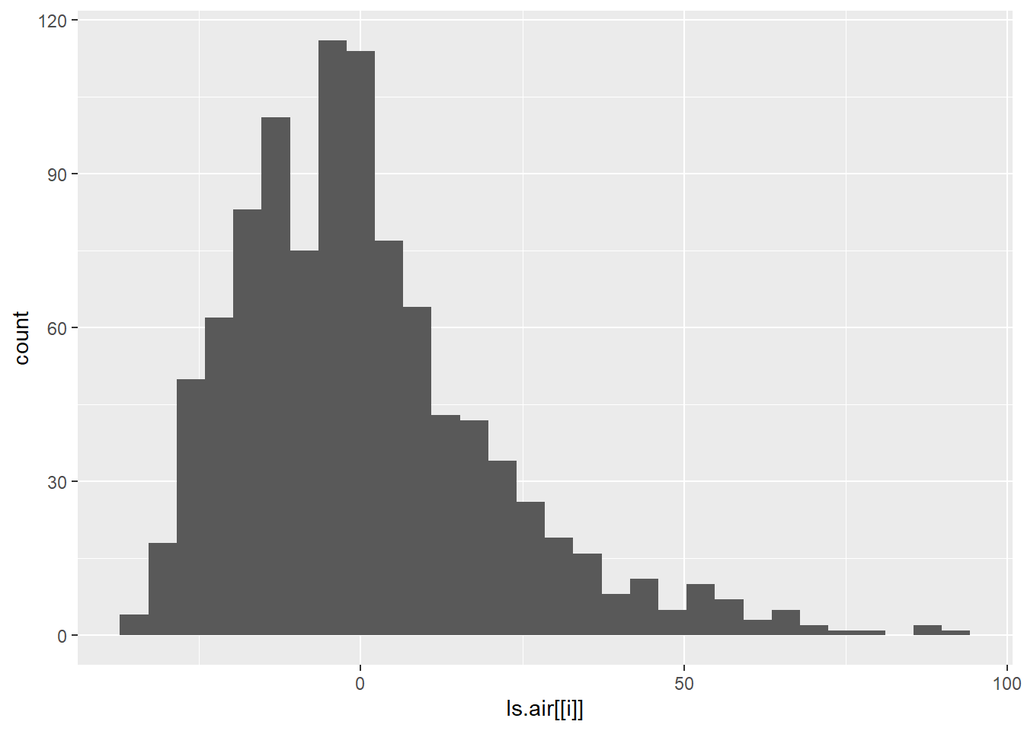

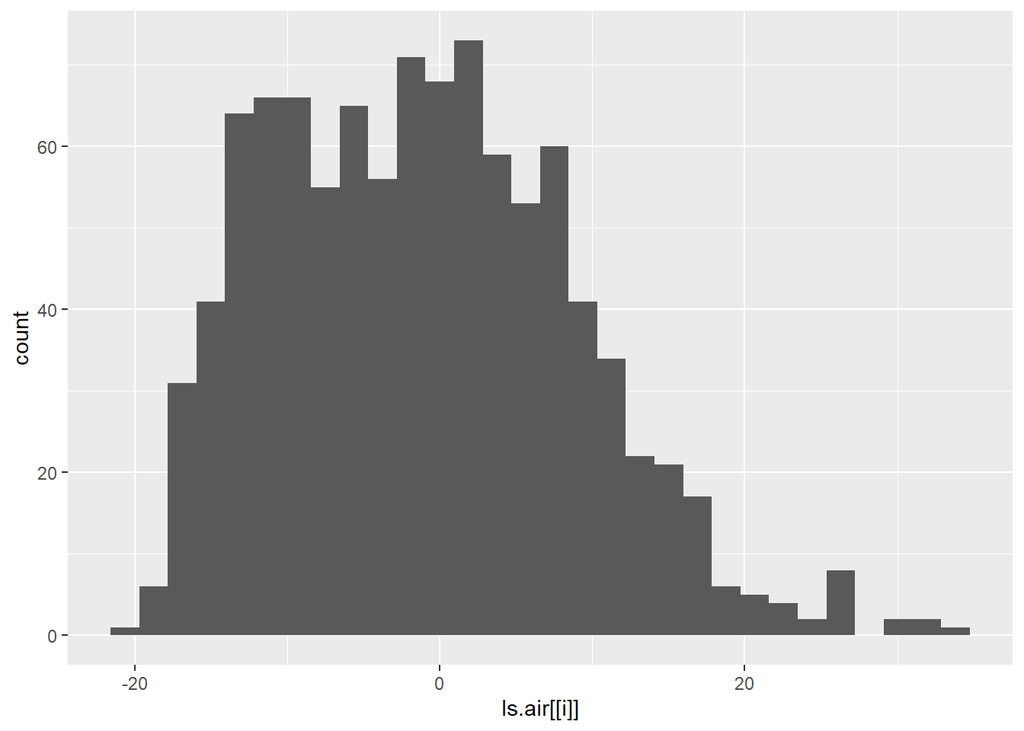

```r
#loop through all columns and plot histograms
for (i in 1:length(ls.air)){
 print(ggplot(air, aes(x = ls.air[[i]])) +
  geom_histogram())
}
```

```r
air$tmpd_scale <- scale(air$tmpd)
air$linear_pm25_scale <- scale(air$linear_pm25)
air$linear_pm10_scale <- scale(air$linear_pm10)
air$o3median_scale <- scale(air$o3median)

head(air)
```

```
## # A tibble: 6 x 10
##     Day  tmpd linear_pm25 linear_pm10 o3median death tmpd_scale[,1]
##   <dbl> <dbl>       <dbl>       <dbl>    <dbl> <dbl>          <dbl>
## 1     1    35       11.5       54.3     -14.3    123         -1.07
## 2     2    39       11.5       33.9     -12.9    125         -0.849
## 3     3    41       10.4        0.254   -15.1    136         -0.737
## 4     4    35        9.20     -20.8      -5.37   116         -1.07
## 5     5    36        8.04       3.11    -11.0    119         -1.02
## 6     6    38        6.88       0.152   -12.4    135         -0.905
## # ... with 3 more variables: linear_pm25_scale <dbl[,1]>,
## #   linear_pm10_scale <dbl[,1]>, o3median_scale <dbl[,1]>
```

```r
air.full <- air

#select relevant variables for air quality
air <- select(air, c(death, tmpd_scale, linear_pm10_scale, linear_pm25_scale, o3median_scale))
```

#### Train-test split

```r
set.seed(1)
in.train <- createDataPartition(air$death, p = .75, list = F)
train.air <- air[in.train,]
test.air <- air[-in.train,]
```

Though I show four basis functions below, I eventually chose to use GAM, cubic spline, and LOESS basis functions in comparing model performance.

This is because there does not seem to be sharp discontinuities in the data except for the relationship of “day” with log(deaths), and even then, the relationship seems to look like what a polynomial function could characterize. Therefore, functions that describe smoother trends might be better fits for the data at hand, and I eliminated the step function and MARS. The reason I eliminated the polynomial was because most of the data did not show a polynomial trend, and another basis function depicting a smoother trend or allowing for more flexibility (e.g. splines) might be a better fit.

#### Develop models with basis functions

##### Polynomial

```r
poly <- lm(log(death) ~ poly(tmpd_scale, degree = 3) +
             poly(linear_pm25_scale, degree = 2) +
             poly(linear_pm10_scale,degree = 2) +
             poly(o3median_scale, degree = 2),
           data = train.air)
summary(poly)
```

```
##
## Call:
## lm(formula = log(death) ~ poly(tmpd_scale, degree = 3) + poly(linear_pm25_scale,
##     degree = 2) + poly(linear_pm10_scale, degree = 2) + poly(o3median_scale,
##     degree = 2), data = train.air)
##
## Residuals:
##      Min       1Q   Median       3Q      Max
## -0.31920 -0.07735  0.00575  0.07303  0.31719
##
## Coefficients:
##                                       Estimate Std. Error  t value Pr(>|t|)
## (Intercept)                           4.696331   0.004123 1138.946  < 2e-16 ***
## poly(tmpd_scale, degree = 3)1        -2.026596   0.147655  -13.725  < 2e-16 ***
## poly(tmpd_scale, degree = 3)2         0.350117   0.124114    2.821  0.00492 **
## poly(tmpd_scale, degree = 3)3         0.635297   0.117588    5.403 8.85e-08 ***
## poly(linear_pm25_scale, degree = 2)1  0.034117   0.133978    0.255  0.79907
## poly(linear_pm25_scale, degree = 2)2 -0.201363   0.118801   -1.695  0.09050 .
## poly(linear_pm10_scale, degree = 2)1  0.751736   0.138546    5.426 7.81e-08 ***
## poly(linear_pm10_scale, degree = 2)2  0.149213   0.124549    1.198  0.23129
## poly(o3median_scale, degree = 2)1    -0.085564   0.145364   -0.589  0.55630
## poly(o3median_scale, degree = 2)2     0.118596   0.118619    1.000  0.31773
## ---
## Signif. codes:  0 '***' 0.001 '**' 0.01 '*' 0.05 '.' 0.1 ' ' 1
##
## Residual standard error: 0.1131 on 742 degrees of freedom
## Multiple R-squared:  0.3251, Adjusted R-squared:  0.317
## F-statistic: 39.72 on 9 and 742 DF,  p-value: < 2.2e-16
```

##### Cubic spline

```r
spline <- lm(log(death) ~
              bs(tmpd_scale + linear_pm25_scale + linear_pm10_scale + o3median_scale, knots = c(360, 720)),
            data = train.air)
# glm(log(death) ~ ns(tmpd_scale + linear_pm25_scale + linear_pm10_scale + o3median_scale, 3), data = train.air)
summary(spline)
```

```
##
## Call:
## lm(formula = log(death) ~ bs(tmpd_scale + linear_pm25_scale +
##     linear_pm10_scale + o3median_scale, knots = c(360, 720)),
##     data = train.air)
##
## Residuals:
##      Min       1Q   Median       3Q      Max
## -0.38832 -0.08319 -0.00617  0.08467  0.41522
##
## Coefficients: (2 not defined because of singularities)
##                                                                                               Estimate
## (Intercept)                                                                                    4.85612
## bs(tmpd_scale + linear_pm25_scale + linear_pm10_scale + o3median_scale, knots = c(360, 720))1 -0.36653
## bs(tmpd_scale + linear_pm25_scale + linear_pm10_scale + o3median_scale, knots = c(360, 720))2 -0.11003
## bs(tmpd_scale + linear_pm25_scale + linear_pm10_scale + o3median_scale, knots = c(360, 720))3 -0.14793
## bs(tmpd_scale + linear_pm25_scale + linear_pm10_scale + o3median_scale, knots = c(360, 720))4       NA
## bs(tmpd_scale + linear_pm25_scale + linear_pm10_scale + o3median_scale, knots = c(360, 720))5       NA
##                                                                                               Std. Error
## (Intercept)                                                                                      0.02292
## bs(tmpd_scale + linear_pm25_scale + linear_pm10_scale + o3median_scale, knots = c(360, 720))1    0.07401
## bs(tmpd_scale + linear_pm25_scale + linear_pm10_scale + o3median_scale, knots = c(360, 720))2    0.06913
## bs(tmpd_scale + linear_pm25_scale + linear_pm10_scale + o3median_scale, knots = c(360, 720))3    0.09803
## bs(tmpd_scale + linear_pm25_scale + linear_pm10_scale + o3median_scale, knots = c(360, 720))4         NA
## bs(tmpd_scale + linear_pm25_scale + linear_pm10_scale + o3median_scale, knots = c(360, 720))5         NA
##                                                                                               t value
## (Intercept)                                                                                   211.840
## bs(tmpd_scale + linear_pm25_scale + linear_pm10_scale + o3median_scale, knots = c(360, 720))1  -4.953
## bs(tmpd_scale + linear_pm25_scale + linear_pm10_scale + o3median_scale, knots = c(360, 720))2  -1.592
## bs(tmpd_scale + linear_pm25_scale + linear_pm10_scale + o3median_scale, knots = c(360, 720))3  -1.509
## bs(tmpd_scale + linear_pm25_scale + linear_pm10_scale + o3median_scale, knots = c(360, 720))4      NA
## bs(tmpd_scale + linear_pm25_scale + linear_pm10_scale + o3median_scale, knots = c(360, 720))5      NA
##                                                                                               Pr(>|t|)
## (Intercept)                                                                                    < 2e-16
## bs(tmpd_scale + linear_pm25_scale + linear_pm10_scale + o3median_scale, knots = c(360, 720))1 9.06e-07
## bs(tmpd_scale + linear_pm25_scale + linear_pm10_scale + o3median_scale, knots = c(360, 720))2    0.112
## bs(tmpd_scale + linear_pm25_scale + linear_pm10_scale + o3median_scale, knots = c(360, 720))3    0.132
## bs(tmpd_scale + linear_pm25_scale + linear_pm10_scale + o3median_scale, knots = c(360, 720))4       NA
## bs(tmpd_scale + linear_pm25_scale + linear_pm10_scale + o3median_scale, knots = c(360, 720))5       NA
##
## (Intercept)                                                                                   ***
## bs(tmpd_scale + linear_pm25_scale + linear_pm10_scale + o3median_scale, knots = c(360, 720))1 ***
## bs(tmpd_scale + linear_pm25_scale + linear_pm10_scale + o3median_scale, knots = c(360, 720))2
## bs(tmpd_scale + linear_pm25_scale + linear_pm10_scale + o3median_scale, knots = c(360, 720))3
## bs(tmpd_scale + linear_pm25_scale + linear_pm10_scale + o3median_scale, knots = c(360, 720))4
## bs(tmpd_scale + linear_pm25_scale + linear_pm10_scale + o3median_scale, knots = c(360, 720))5
## ---
## Signif. codes:  0 '***' 0.001 '**' 0.01 '*' 0.05 '.' 0.1 ' ' 1
##
## Residual standard error: 0.1301 on 748 degrees of freedom
## Multiple R-squared:  0.09942,    Adjusted R-squared:  0.0958
## F-statistic: 27.52 on 3 and 748 DF,  p-value: < 2.2e-16
```

##### LOESS

```r
library(stats)
loess <- loess(log(death) ~ tmpd_scale +
                 linear_pm25_scale +
                 linear_pm10_scale +
                 o3median_scale,
               data = train.air,
               span = 0.7)
summary(loess)
```

```
## Call:
## loess(formula = log(death) ~ tmpd_scale + linear_pm25_scale +
##     linear_pm10_scale + o3median_scale, data = train.air, span = 0.7)
##
## Number of Observations: 752
## Equivalent Number of Parameters: 27.59
## Residual Standard Error: 0.1178
## Trace of smoother matrix: 34.88  (exact)
##
## Control settings:
##   span     :  0.7
##   degree   :  2
##   family   :  gaussian
##   surface  :  interpolate      cell = 0.2
##   normalize:  TRUE
##  parametric:  FALSE FALSE FALSE FALSE
## drop.square:  FALSE FALSE FALSE FALSE
```

#### GAM

```r
gam <- gam(formula = (log(death) ~ tmpd_scale +
          linear_pm25_scale +
          linear_pm10_scale +
          o3median_scale),
      data = train.air,
    family = gaussian)
summary(gam)
```

```
##
## Call: gam(formula = (log(death) ~ tmpd_scale + linear_pm25_scale +
##     linear_pm10_scale + o3median_scale), family = gaussian, data = train.air)
## Deviance Residuals:
##       Min        1Q    Median        3Q       Max
## -0.324473 -0.076433  0.004611  0.074461  0.362074
##
## (Dispersion Parameter for gaussian family taken to be 0.0135)
##
##     Null Deviance: 14.0578 on 751 degrees of freedom
## Residual Deviance: 10.0631 on 747 degrees of freedom
## AIC: -1097.941
##
## Number of Local Scoring Iterations: 2
##
## Anova for Parametric Effects
##                    Df  Sum Sq Mean Sq  F value    Pr(>F)
## tmpd_scale          1  3.3514  3.3514 248.7801 < 2.2e-16 ***
## linear_pm25_scale   1  0.2139  0.2139  15.8810 7.407e-05 ***
## linear_pm10_scale   1  0.4031  0.4031  29.9245 6.132e-08 ***
## o3median_scale      1  0.0262  0.0262   1.9461    0.1634
## Residuals         747 10.0631  0.0135
## ---
## Signif. codes:  0 '***' 0.001 '**' 0.01 '*' 0.05 '.' 0.1 ' ' 1
```

From the above results, we see that air quality does to an extent predict deaths, though not all air quality measures are significant when controlling for other air quality parameters.

#### Use cross-validation to evaluate performance

```r
#create folds
nrow.air <- nrow(air)
V <- 10
set.seed(1)
folds <- split(sample(1:nrow.air), rep(1:V, length = nrow.air))

#create matrix for dumping cv results
cvOUT <- matrix(NA, nrow = 10, ncol = 3)
colnames(cvOUT) <- c("gam", "spline", "loess")
```

##### GAM

```r
for(v in 1:V) {
  tmp_train <- air[-folds[[v]], ]
  tmp_test <- air[folds[[v]], ]
  gam <- gam(formula = (log(death) ~ tmpd_scale +
          linear_pm25_scale +
          linear_pm10_scale +
          o3median_scale),
      data = train.air,
    family = gaussian)
# estimate MSE on held out fold set
cvOUT[v, 1] <- mean((tmp_test$death - exp(predict(gam, newdata = tmp_train)))^2)
}
```

##### Cubic spline

```r
for(v in 1:V) {
  tmp_train <- air[-folds[[v]], ]
  tmp_test <- air[folds[[v]], ]
  spline <- glm(log(death) ~
                ns(tmpd_scale +
                     linear_pm25_scale +
                     linear_pm10_scale +
                     o3median_scale, 3),
              data = tmp_train)

# estimate MSE on held out fold set
cvOUT[v, 2] <- mean((tmp_test$death - exp(predict(spline, newdata = tmp_test)))^2)
}
```

##### LOESS

```r
for(v in 1:V) {
  tmp_train <- air[-folds[[v]], ]
  tmp_test <- air[folds[[v]], ]
  loess <- loess(log(death) ~ tmpd_scale +
                 linear_pm25_scale +
                 linear_pm10_scale +
                 o3median_scale,
               data = tmp_train,
               span = 0.8)

# estimate MSE on held out fold set
cvOUT[v, 3] <- mean((tmp_test$death - exp(predict(loess, newdata = tmp_test)))^2)
}
```

#### CV error comparison

```r
cvOUT
```

```
##            gam   spline    loess
##  [1,] 329.6546 237.3964 187.8655
##  [2,] 252.3144 167.7853       NA
##  [3,] 273.2464 194.5374       NA
##  [4,] 312.9823 217.5855       NA
##  [5,] 238.5019 168.3093       NA
##  [6,] 277.8540 186.5074       NA
##  [7,] 326.4045 225.5991       NA
##  [8,] 343.2905 222.4520 166.4836
##  [9,] 311.9686 261.0478       NA
## [10,] 323.4143 234.4168 186.5772
```

```r
summary(cvOUT)
```

```
##       gam            spline          loess
##  Min.   :238.5   Min.   :167.8   Min.   :166.5
##  1st Qu.:274.4   1st Qu.:188.5   1st Qu.:176.5
##  Median :312.5   Median :220.0   Median :186.6
##  Mean   :299.0   Mean   :211.6   Mean   :180.3
##  3rd Qu.:325.7   3rd Qu.:232.2   3rd Qu.:187.2
##  Max.   :343.3   Max.   :261.0   Max.   :187.9
##                                  NA's   :7
```

#### Conclusion

It seems that out of the three basis functions, LOESS showed the best performance, followed by cubic spline, and then GAM, in terms of cross-validation MSE.

GAM generated higher MSE values than both cubic spline and LOESS. The MSE for cubic splines fluctuated in different folds, but was much lower than that of GAM’s on average . LOESS seems to have produced NAs in the cross-validation process, but the MSE that it did produce were quite low in comparison to the other two basis functions.

### 2. Also on canvas is a de-identified dataset called `HW2_dataset.csv`.

The dataset has been modified to be completely de-identified and all variables names anonymized. The outcome variable is Y, and X1 through X125 are potential features representing a mixture of variable types (binary, categorical, and continuous).

The task is to compare a series of regularized regression predictors using the squared error loss function. Consider the following methods:

```
1. Regular Linear Regression
2. Ridge Regression
3. Lasso Regression
4. Elastic Net Regression
```

```r
#read in libraries and data
library(glmnet)
library(gamlr)
hw2 <- read_csv("HW2_dataset.csv")
head(hw2)
```

```
## # A tibble: 6 x 126
##        Y    X1     X2     X3    X4    X5     X6     X7     X8     X9    X10
##    <dbl> <dbl>  <dbl>  <dbl> <dbl> <dbl>  <dbl>  <dbl>  <dbl>  <dbl>  <dbl>
## 1  3.50   -0.5  0.194 -3.00   -2.5 0.478 -0.936  1.08  -2.03   0.743 -0.978
## 2 33.1    -0.3 -2.64  -0.779   1.3 0.42   1.81   2.39   0.14  -1.42  -4.82
## 3 -0.949  -0.6  2.47   1.36    0.8 0.561 -2.61  -0.145  3.48  -1.20   0.861
## 4 -6.43   -3.3  0.229 -3.60    5.2 0.424 -0.98   1.67  -1.08   0.392 -1.58
## 5 31.9    -1.5  1.12   2.47    2.2 0.553  0.81   1.17  -0.971  0.2    0.482
## 6 21.2    -3.2  2.26   0.368  -0.7 0.425  0.347 -0.601 -0.806 -0.41  -2.82
## # ... with 115 more variables: X11 <dbl>, X12 <dbl>, X13 <dbl>, X14 <dbl>,
## #   X15 <dbl>, X16 <dbl>, X17 <dbl>, X18 <dbl>, X19 <dbl>, X20 <dbl>,
## #   X21 <dbl>, X22 <dbl>, X23 <dbl>, X24 <dbl>, X25 <dbl>, X26 <dbl>,
## #   X27 <dbl>, X28 <dbl>, X29 <dbl>, X30 <dbl>, X31 <dbl>, X32 <dbl>,
## #   X33 <dbl>, X34 <dbl>, X35 <dbl>, X36 <dbl>, X37 <dbl>, X38 <dbl>,
## #   X39 <dbl>, X40 <dbl>, X41 <dbl>, X42 <dbl>, X43 <dbl>, X44 <dbl>,
## #   X45 <dbl>, X46 <dbl>, X47 <dbl>, X48 <dbl>, X49 <dbl>, X50 <dbl>, ...
```

```r
#manipulate data types
hw2 <- hw2 %>% mutate_if(is.character, as.factor)
hw2
```

```
## # A tibble: 914 x 126
##         Y    X1     X2     X3    X4    X5     X6     X7     X8     X9    X10
##     <dbl> <dbl>  <dbl>  <dbl> <dbl> <dbl>  <dbl>  <dbl>  <dbl>  <dbl>  <dbl>
##  1  3.50   -0.5  0.194 -3.00   -2.5 0.478 -0.936  1.08  -2.03   0.743 -0.978
##  2 33.1    -0.3 -2.64  -0.779   1.3 0.42   1.81   2.39   0.14  -1.42  -4.82
##  3 -0.949  -0.6  2.47   1.36    0.8 0.561 -2.61  -0.145  3.48  -1.20   0.861
##  4 -6.43   -3.3  0.229 -3.60    5.2 0.424 -0.98   1.67  -1.08   0.392 -1.58
##  5 31.9    -1.5  1.12   2.47    2.2 0.553  0.81   1.17  -0.971  0.2    0.482
##  6 21.2    -3.2  2.26   0.368  -0.7 0.425  0.347 -0.601 -0.806 -0.41  -2.82
##  7 15.7     1.1 -1.29   2.16    1.3 0.571  2.15  -1.02   0.218 -3.69   1.67
##  8  9.13   -0.1 -0.967  1.86   -1.7 0.507 -1.54   0.103 -0.2   -3.68   0.987
##  9 21.6     2.6  1.23  -0.762  -0.5 0.519  0.431 -1.07   2.44  -1.14  -2.12
## 10 -8.09    0.2  2.50   0.864   0.1 0.573  1.87  -3.43  -2.46   0.925 -2.24
## # ... with 904 more rows, and 115 more variables: X11 <dbl>, X12 <dbl>,
## #   X13 <dbl>, X14 <dbl>, X15 <dbl>, X16 <dbl>, X17 <dbl>, X18 <dbl>,
## #   X19 <dbl>, X20 <dbl>, X21 <dbl>, X22 <dbl>, X23 <dbl>, X24 <dbl>,
## #   X25 <dbl>, X26 <dbl>, X27 <dbl>, X28 <dbl>, X29 <dbl>, X30 <dbl>,
## #   X31 <dbl>, X32 <dbl>, X33 <dbl>, X34 <dbl>, X35 <dbl>, X36 <dbl>,
## #   X37 <dbl>, X38 <dbl>, X39 <dbl>, X40 <dbl>, X41 <dbl>, X42 <dbl>,
## #   X43 <dbl>, X44 <dbl>, X45 <dbl>, X46 <dbl>, X47 <dbl>, X48 <dbl>, ...
```

```r
levels(hw2$X93)
```

```
## [1] "A" "B" "C"
```

```r
levels(hw2$X119)
```

```
## [1] "A" "B" "C" "D"
```

```r
mutate(hw2, X93 = as.factor(ifelse(X93 == 'A', 1,
                         ifelse(X93 == 'B', 2,
                         ifelse(X93 == 'C', 3, NA)))))
```

```
## # A tibble: 914 x 126
##         Y    X1     X2     X3    X4    X5     X6     X7     X8     X9    X10
##     <dbl> <dbl>  <dbl>  <dbl> <dbl> <dbl>  <dbl>  <dbl>  <dbl>  <dbl>  <dbl>
##  1  3.50   -0.5  0.194 -3.00   -2.5 0.478 -0.936  1.08  -2.03   0.743 -0.978
##  2 33.1    -0.3 -2.64  -0.779   1.3 0.42   1.81   2.39   0.14  -1.42  -4.82
##  3 -0.949  -0.6  2.47   1.36    0.8 0.561 -2.61  -0.145  3.48  -1.20   0.861
##  4 -6.43   -3.3  0.229 -3.60    5.2 0.424 -0.98   1.67  -1.08   0.392 -1.58
##  5 31.9    -1.5  1.12   2.47    2.2 0.553  0.81   1.17  -0.971  0.2    0.482
##  6 21.2    -3.2  2.26   0.368  -0.7 0.425  0.347 -0.601 -0.806 -0.41  -2.82
##  7 15.7     1.1 -1.29   2.16    1.3 0.571  2.15  -1.02   0.218 -3.69   1.67
##  8  9.13   -0.1 -0.967  1.86   -1.7 0.507 -1.54   0.103 -0.2   -3.68   0.987
##  9 21.6     2.6  1.23  -0.762  -0.5 0.519  0.431 -1.07   2.44  -1.14  -2.12
## 10 -8.09    0.2  2.50   0.864   0.1 0.573  1.87  -3.43  -2.46   0.925 -2.24
## # ... with 904 more rows, and 115 more variables: X11 <dbl>, X12 <dbl>,
## #   X13 <dbl>, X14 <dbl>, X15 <dbl>, X16 <dbl>, X17 <dbl>, X18 <dbl>,
## #   X19 <dbl>, X20 <dbl>, X21 <dbl>, X22 <dbl>, X23 <dbl>, X24 <dbl>,
## #   X25 <dbl>, X26 <dbl>, X27 <dbl>, X28 <dbl>, X29 <dbl>, X30 <dbl>,
## #   X31 <dbl>, X32 <dbl>, X33 <dbl>, X34 <dbl>, X35 <dbl>, X36 <dbl>,
## #   X37 <dbl>, X38 <dbl>, X39 <dbl>, X40 <dbl>, X41 <dbl>, X42 <dbl>,
## #   X43 <dbl>, X44 <dbl>, X45 <dbl>, X46 <dbl>, X47 <dbl>, X48 <dbl>, ...
```

```r
mutate(hw2, X119 = as.factor(ifelse(X119 == 'A', 1,
                         ifelse(X119 == 'B', 2,
                         ifelse(X119 == 'C', 3,
                         ifelse(X119 == 'D', 4, NA))))))
```

```
## # A tibble: 914 x 126
##         Y    X1     X2     X3    X4    X5     X6     X7     X8     X9    X10
##     <dbl> <dbl>  <dbl>  <dbl> <dbl> <dbl>  <dbl>  <dbl>  <dbl>  <dbl>  <dbl>
##  1  3.50   -0.5  0.194 -3.00   -2.5 0.478 -0.936  1.08  -2.03   0.743 -0.978
##  2 33.1    -0.3 -2.64  -0.779   1.3 0.42   1.81   2.39   0.14  -1.42  -4.82
##  3 -0.949  -0.6  2.47   1.36    0.8 0.561 -2.61  -0.145  3.48  -1.20   0.861
##  4 -6.43   -3.3  0.229 -3.60    5.2 0.424 -0.98   1.67  -1.08   0.392 -1.58
##  5 31.9    -1.5  1.12   2.47    2.2 0.553  0.81   1.17  -0.971  0.2    0.482
##  6 21.2    -3.2  2.26   0.368  -0.7 0.425  0.347 -0.601 -0.806 -0.41  -2.82
##  7 15.7     1.1 -1.29   2.16    1.3 0.571  2.15  -1.02   0.218 -3.69   1.67
##  8  9.13   -0.1 -0.967  1.86   -1.7 0.507 -1.54   0.103 -0.2   -3.68   0.987
##  9 21.6     2.6  1.23  -0.762  -0.5 0.519  0.431 -1.07   2.44  -1.14  -2.12
## 10 -8.09    0.2  2.50   0.864   0.1 0.573  1.87  -3.43  -2.46   0.925 -2.24
## # ... with 904 more rows, and 115 more variables: X11 <dbl>, X12 <dbl>,
## #   X13 <dbl>, X14 <dbl>, X15 <dbl>, X16 <dbl>, X17 <dbl>, X18 <dbl>,
## #   X19 <dbl>, X20 <dbl>, X21 <dbl>, X22 <dbl>, X23 <dbl>, X24 <dbl>,
## #   X25 <dbl>, X26 <dbl>, X27 <dbl>, X28 <dbl>, X29 <dbl>, X30 <dbl>,
## #   X31 <dbl>, X32 <dbl>, X33 <dbl>, X34 <dbl>, X35 <dbl>, X36 <dbl>,
## #   X37 <dbl>, X38 <dbl>, X39 <dbl>, X40 <dbl>, X41 <dbl>, X42 <dbl>,
## #   X43 <dbl>, X44 <dbl>, X45 <dbl>, X46 <dbl>, X47 <dbl>, X48 <dbl>, ...
```

#### Split data into training and testing datasets

```r
library(caret)
set.seed(1)
in.train <- createDataPartition(hw2$Y, p = .75, list = F)

#train test split
#for linear model
lm.train <- hw2[in.train,]
lm.test <- hw2[-in.train,]

#for regularization methods
train <- hw2[in.train,]
y.train <- as.numeric(train$Y)
train <- model.matrix(Y ~ ., data = train)[,-1]

test <- hw2[-in.train,]
y.test <- as.numeric(test$Y)
test <- model.matrix(Y ~ ., data = test)[,-1]
```

#### Build models

```r
lm <- lm(Y ~ ., data = lm.train)
summary(lm)

ridge <- cv.glmnet(train, y.train, alpha = 0, standardize = T, type.measure = "mse", nfolds = 5)
coef(ridge)

lasso <- cv.glmnet(train, y.train, alpha = 1, standardize = T, type.measure = "mse", nfolds = 5)
coef(lasso)

net <- cv.glmnet(train, y.train, alpha = 0.5, standardize = T, type.measure = "mse", nfolds = 5)
coef(net)
```

[output not shown]

#### How do the different parameter estimates vary across these methods with the dataset?

It is obvious that LASSO and Elastic Net shrunk most coefficients to 0 and only retained the most relevant predictors, while ridge regression shrunk many coefficients close to 0 but not precisely 0.

This fits with the intuition that we built in class–LASSO will shrink coefficients to exactly 0, while ridge regression would penalize less relevant coefficients but not set them to exactly 0. While Elastic Net is essentially a tradeoff between LASSO and ridge regression, it seems that the Elastic Net here shrunk most coefficients to 0 but retained slightly more coefficients than LASSO.

```r
coef.df <- data.frame(lm = coef(lm),
           ridge = as.numeric(coef(ridge)),
           lasso = as.numeric(coef(lasso)),
           elastic_net = as.numeric(coef(net)))
coef.df
```

```
##                       lm        ridge      lasso elastic_net
## (Intercept)  3.649000137  6.764315658  7.8121409  7.31918686
## X1           1.928600963  0.974963670  1.0898468  1.24229062
## X2          -0.053229069 -0.072365339  0.0000000  0.00000000
## X3          -0.198915886 -0.084581424  0.0000000  0.00000000
## X4           0.167582731  0.044598458  0.0000000  0.00000000
## X5           1.184373443  1.666420111  0.0000000  0.00000000
## X6          -0.008298026  0.010229366  0.0000000  0.00000000
## X7          -0.097769060 -0.090905594  0.0000000  0.00000000
## X8           0.135586465  0.038995543  0.0000000  0.00000000
## X9          -0.030637790  0.019166053  0.0000000  0.00000000
## X10         -0.111753523 -0.095797499  0.0000000  0.00000000
## X11         -0.140998366 -0.034626389  0.0000000  0.00000000
## X12          0.103925905  0.047205911  0.0000000  0.00000000
## X13         -1.386186087 -0.125476105  0.0000000  0.00000000
## X14         -5.149198252  0.553288028  0.0000000  0.00000000
## X15         -0.015476316 -0.037290801  0.0000000  0.00000000
## X16         -0.018847980 -0.020909516  0.0000000  0.00000000
## X17          0.450731081  0.128188029  0.0000000  0.00000000
## X18         -0.008216475 -0.022131932  0.0000000  0.00000000
## X19         -2.438337154 -0.672320746  0.0000000  0.00000000
## X20         -0.390830050 -0.159391996  0.0000000  0.00000000
## X21          0.092738570 -0.028264783  0.0000000  0.00000000
## X22         -0.123528801 -0.021713119  0.0000000  0.00000000
## X23          0.031355252  0.032073666  0.0000000  0.00000000
## X24          0.332637412  0.106960515  0.0000000  0.00000000
## X25          0.105081399  0.083551570  0.0000000  0.00000000
## X26          0.063130973  0.022433398  0.0000000  0.00000000
## X27          0.165685782  0.089008525  0.0000000  0.00000000
## X28          1.998743182  1.869343819  0.6040919  1.36052098
## X29         -0.088579392 -0.037698502  0.0000000  0.00000000
## X30         -0.129437789 -0.071736145  0.0000000  0.00000000
## X31          0.180529555  0.112747321  0.0000000  0.00000000
## X32         -0.197942766 -0.117166909  0.0000000  0.00000000
## X33          0.140534530  0.136788418  0.0000000  0.00000000
## X34          1.962048962  1.040778241  1.8738410  1.87906116
## X35         -0.213225749 -0.073716407  0.0000000  0.00000000
## X36          0.303804106  0.093883522  0.0000000  0.00000000
## X37          0.076349481  0.015420648  0.0000000  0.00000000
## X38          0.148761033  0.088256134  0.0000000  0.00000000
```

[output cut: 76 more lines]

```
## X113         0.121065819 -0.015422676  0.0000000  0.00000000
## X114         0.680578368  0.231167537  0.0000000  0.02922546
## X115        -0.082167517 -0.090996203  0.0000000  0.00000000
## X116        -0.058574871 -0.104252012  0.0000000  0.00000000
## X117        -0.303756591 -0.199601513  0.0000000  0.00000000
## X118        -0.051567645  0.023586260  0.0000000  0.00000000
## X119B       -2.595382996 -0.508929587  0.0000000  0.00000000
## X119C       -1.612285213 -0.339371879  0.0000000  0.00000000
## X119D        0.128911573  0.811442635  0.0000000  0.00000000
## X120         0.059213181 -0.073968694  0.0000000  0.00000000
## X121        -0.138493176 -0.095150852  0.0000000  0.00000000
## X122        -0.038043503 -0.047366615  0.0000000  0.00000000
## X123         0.087942472  0.042767206  0.0000000  0.00000000
## X124        -0.268529542  0.740879592  0.0000000  0.00000000
## X125         0.312418874  0.231357668  0.0000000  0.00000000
```

#### Which method appears to perform best?

##### Linear model

```r
lm.predictions <- predict(lm, newdata = lm.test)
lm.mse <- mean((y.test - lm.predictions)^2)
cat("Linear model MSE:", lm.mse, "\n")
```

```
## Linear model MSE: 149.6171
```

##### Regularization methods

```r
#calculate MSE for LASSO, ridge, and elastic net (with all values of alpha != 0 or 1)
ls.fit <- list()
for (i in 0:10){
  fit.num <- paste0("alpha = ", i/10)

  ls.fit[[fit.num]] <- cv.glmnet(train, y.train, type.measure = "mse", alpha = i/10)
}
ls.fit
```

```
## $`alpha = 0`
##
## Call:  cv.glmnet(x = train, y = y.train, type.measure = "mse", alpha = i/10)
##
## Measure: Mean-Squared Error
##
##     Lambda Index Measure    SE Nonzero
## min  7.476    74   134.8 8.197     129
## 1se 22.831    62   142.4 7.118     129
##
## $`alpha = 0.1`
##
## Call:  cv.glmnet(x = train, y = y.train, type.measure = "mse", alpha = i/10)
##
## Measure: Mean-Squared Error
##
##     Lambda Index Measure    SE Nonzero
## min  4.084    31   123.9 6.937      41
## 1se  8.596    23   130.2 7.237      15
##
## $`alpha = 0.2`
##
## Call:  cv.glmnet(x = train, y = y.train, type.measure = "mse", alpha = i/10)
##
## Measure: Mean-Squared Error
##
##     Lambda Index Measure    SE Nonzero
## min  2.699    28   119.8 5.585      26
## 1se  4.717    22   124.6 5.225      12
##
## $`alpha = 0.3`
##
## Call:  cv.glmnet(x = train, y = y.train, type.measure = "mse", alpha = i/10)
##
## Measure: Mean-Squared Error
##
##     Lambda Index Measure    SE Nonzero
## min  1.799    28   120.0 2.631      26
## 1se  2.865    23   122.2 3.552      14
##
```

[output cut: 54 more lines]

```
## Measure: Mean-Squared Error
##
##     Lambda Index Measure    SE Nonzero
## min 0.5998    28   117.3 5.052      25
## 1se 1.2625    20   122.1 4.859       7
##
## $`alpha = 1`
##
## Call:  cv.glmnet(x = train, y = y.train, type.measure = "mse", alpha = i/10)
##
## Measure: Mean-Squared Error
##
##     Lambda Index Measure    SE Nonzero
## min 0.6502    26   117.7 5.067      15
## 1se 1.2471    19   122.7 5.093       6
```

```r
results <- data.frame()
for (i in 0:10){
  fit.num <- paste0("alpha = ", i/10)

  predictions <- predict(ls.fit[[fit.num]],
                         s = ls.fit[[fit.num]]$lambda.1se, newx = test)

  mse <- mean((y.test - predictions)^2)

  temp <- data.frame(alpha = i/10, mse = mse, fit.name = fit.num)
  results <- rbind(results, temp)
}
results
```

```
##    alpha      mse    fit.name
## 1    0.0 151.7433   alpha = 0
## 2    0.1 133.8674 alpha = 0.1
## 3    0.2 128.6935 alpha = 0.2
## 4    0.3 125.7313 alpha = 0.3
## 5    0.4 127.7609 alpha = 0.4
## 6    0.5 128.4202 alpha = 0.5
## 7    0.6 129.4265 alpha = 0.6
## 8    0.7 126.3397 alpha = 0.7
## 9    0.8 127.3386 alpha = 0.8
## 10   0.9 125.9892 alpha = 0.9
## 11   1.0 127.0320   alpha = 1
```

For LASSO (alpha = 1), MSE = 127.0.

Elactic net had the best performance accoridng to the squared error loss function.